# The impact of age on the interest about minimum wage

Are younger politicians more concerned about this topic?

Chiara Moruzzi

2022-12-22

### Work insights

- Number of commits:18
- Number of issues opened: 1
- Number of pull requests open: 1
- Number of pull requests accepted and merged: 1
- Number of new branches opened: 1

https://github.com/DataAccess2020/Capstone_Chiara_Moruzzi

## Introduction

The research hypothesis can be justified by the fact that legal minimum wage is a policy measure that should help disadvantages groups of workers, such as low-qualified workers, immigrants and young people. I decided to focus on age since, as emerged more and more in the last few years, there are not many policies to help young people to enter in the labour market in Italy, especially compared to other European countries.

## Methodology

First of all I created two lists containing all 400 0f the Italian MPs separated by group:

- Italian MP (under 40): with all the mebers of the Camera dei Deputati born in 1983 or after (48 members); https://twitter.com/i/lists/1601560531244093440
- Italian MP (over 40): with all the mebers of the Camera dei Deputati born before 1983 (250 members). https://twitter.com/i/lists/1601572364214583298

102 members are missing because I could not find them on twitter. To get all the information about age, education, party and twitter handles I used the following website: https://www.camera.it/leg19/28 . Unfortunately, this website contains only a minority of the actual twitter handles of the parliamentarians, so for most of them I had to look them up autonomously. Before choosing whether to put them into the lists or not, I thoroughly checked each profile’s description, posts, followers etc. to make sure those were the actual profiles and not homonyms, fan pages, news pages or anything else. As regards age, the website I linked provides a specific tool to divide MPs by age. First of all I tried to collect all the data in an automatized way, but I couldn’t since I encountered a few difficulties I didn’t manage to overcome:

- as I already said, only a few twitter handles were provided, leaving out most of the MPs from the analysis;
- I could not isolate the age and transform it into a numerical variable, since the birth date was inside a string containing all the personal informationg given by the website;
- I could not iterate the function to create a for loop or to use `lapply()` because the URL of the webpage changed based on letters and not number. I tried many times but I could not overcome this obstacle (example: https://www.camera.it/leg19/28 is the link for page A, https://www.camera.it/leg19/28?lettera=B is the link for page B and so on).

## Workflow

After authenticating to Twitter API, I downloaded information about each list members and put it in a specific summary table for both age groups. The two dataframes contain the following information: screen names, twitter handles, number of tweets and number of followers.

```r
italian_MP_under40 = lists_members(
  list_id = "1601560531244093440",
  slug = NULL,
  owner_user = NULL,
  n = 48,
  cursor = "-1",
  token = NULL,
  retryonratelimit = TRUE,
  verbose = TRUE,
  parse = TRUE,
)
```

```r
DF_MP_under40 <- tibble (MP_under40_names,MP_under40_t_handle, MP_under40_followers, MP_under40_n_tweets)
```

```r
italian_MP_over40 = lists_members(
  list_id = "1601572364214583298",
  slug = NULL,
  owner_user = NULL,
  n = 250,
  cursor = "-1",
  token = NULL,
  retryonratelimit = TRUE,
  verbose = TRUE,
  parse = TRUE,
)
```

```r
DF_MP_under40 <- tibble (MP_under40_names,MP_under40_t_handle, MP_under40_followers, MP_under40_n_tweets)
```

Now that I have the two dataframes with all the information I need, I can extract tweets and evaluate the proportion of those about minimum wage on the total number of tweets. Then, I create a specific dataframe (then unlisted) for each age group containing only the text of the tweets downloaded.

```r
under40_tweets <- for (i in seq_along(italian_MP_under40)){
 under40_tweets = get_timelines(user = italian_MP_under40[[i]],
                                n = Inf,
                                retryonratelimit = T,
                                parse = TRUE,
                                verbose = TRUE,
 Sys.sleep(0.5)) %>%
  dplyr::filter(created_at >= "2022-07-21" & created_at<="2022-09-24")
}

under40_t_text <- c(under40_tweets$full_text)
```

```r
over40_tweets <- for (i in seq_along(italian_MP_over40)){
  over40_tweets = get_timelines(user = italian_MP_over40[[i]],
                                 n = Inf,
                                 retryonratelimit = T,
                                 parse = TRUE,
                                 verbose = TRUE) %>%
    dplyr::filter(created_at >= "2022-07-21" & created_at<="2022-09-24")
}

over40_t_text <- c(over40_tweets$full_text)
```

```r
unl_t_over <- unlist(over40_t_text)
unl_t_under <- unlist(under40_t_text)
```

One group at a time, I extract all the tweets containing the word “salario”. I chose to use the word “salario” instead of “salario minimo” or #salariominimo because after a few attempts I realized this was the best way to capture all the tweets about this issue. In each case the regular expression “salario” returns a tweet about minimum wage; using one of the two keywords I mentioned before would have reported only a part of the total amount of tweets and retweets about this topic.

```r
#UNDER 40
under40_sm <- str_detect(under40_t_text, pattern = "salario")

tweets="salario"
under40_sm = under40_t_text %>%
  str_subset(tweets)

print(under40_sm) #20 out of 3797


#OVER 40

over40_sm <- str_detect(over40_t_text, pattern = "salario")

tweets="salario"
over40_sm = over40_t_text %>%
  str_subset(tweets)

over40_sm %>%
  str_extract(over40_t_text)

print(over40_sm) #120 out of 20582
```

Now that I have the number of tweets about minimum wage, I can evaluate and compare the proportion between the two groups; To do that, i create a specific object containing the number of tweets about minimum wage and an object with the total number of tweets. Finally I create an object to calculate and store the proportion divided by group.

I test the significance of the results obtained through a pr test

```
##
##  1-sample proportions test with continuity correction
##
## data:  n_sm_under40 out of total_under40, null probability 0.5
## X-squared = 3715.4, df = 1, p-value < 2.2e-16
## alternative hypothesis: true p is not equal to 0.5
## 95 percent confidence interval:
##  0.003308983 0.008281557
## sample estimates:
##           p
## 0.005267316
```

```
##
##  1-sample proportions test with continuity correction
##
## data:  n_sm_over40 out of total_over40, null probability 0.5
## X-squared = 20103, df = 1, p-value < 2.2e-16
## alternative hypothesis: true p is not equal to 0.5
## 95 percent confidence interval:
##  0.004856313 0.006993082
## sample estimates:
##           p
## 0.005830337
```

To visualize the results in a better way I plotted the data through a histogram:

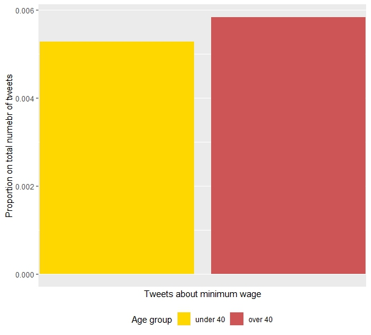

## Conclusions

To summarize what we learn from this research we can point out that, in contrast to the research hypothesis, we observe that, as regards the selected period of time, younger politicians do not seem more concerned then older ones about the introduction of a legal minimum wage in Italy. The aspect that surprised me the most was finding such a small proportion of tweets about this topic: I was aware it was not one of the key issues in the election campaign, but I expected legal minimum wage to be more relevant, especially considering the fact that Italy is one of the very few countries in Europe that still do not have one and this, as I said before, especially affect disadvantaged workers such as young people. In the future it would be interesting to evaluate if education or gender have an influence to the concern about minimum wage.

## Appendix

Considering all the obstacles I faced, I decided to create a .dta dataset containing information about the XIX Legislatura Members of the Camera dei Deputati data; it was a really long process since I double checked each information I put, but I figured it would be a very useful tool both for mine and other researchers’ future works. The dataset, as it is now, contains the following information for each parliamentary:

- Name and Surname;
- Party;
- Year of birth;
- Twitter handle (if there is one);
- Education level;
- Gender.

Through this dataset I managed to describe the distribution a bit better: first I created a variable for age and then I plotted the distribution. The average age for Italian members of the “Camera dei deputati” is 49.57 years old. The youngest parliamentary is 25 and the oldest one is 81 years old.

```
##    Min. 1st Qu.  Median    Mean 3rd Qu.    Max.
##   25.00   42.00   49.00   49.57   56.00   81.00
```

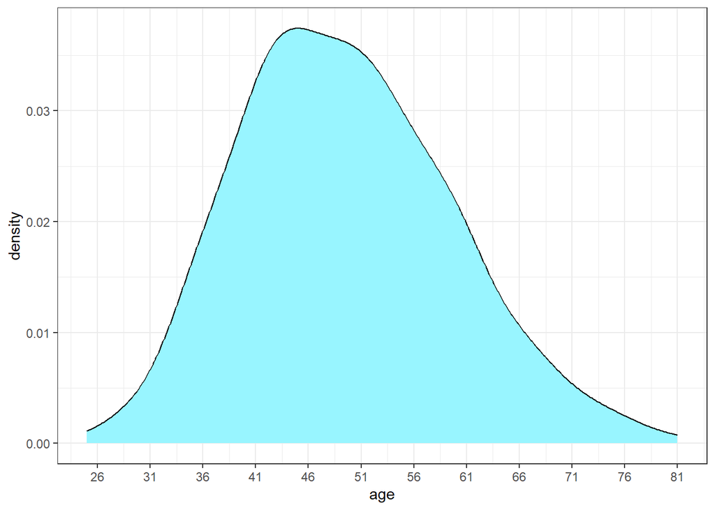

I imported the data set in the folder “Data” hoping to improve it with more information in the future. Everyone who needs it is welcome to use it and update the data contained with more information.